# Lab 1

## Variance of normal RV-s

Let’s compute the sample variance of normal random variables by Monte Carlo (MC) simulations. With sample size *n = 1000*, let’s generate n samples to work with.

```r
n <- 1000
sample <- rnorm(n)
sample_mean <- mean(sample)
```

The mean of this sample is 0.0323814, which is unsurprisingly very close to 0. Next, let’s explore different ways of finding variance of this sample.

```r
sample_variance <- mean((sample - sample_mean)^2)
shortcut_variance <- mean((sample^2)) - mean(sample)^2
var_variance <- var(sample)
```

Following the formula **Var X = E[(X - E X)^2]**, we get **1.0312625**. Using the shortcut formula **Var X = E x^2 - (E X)^2**, we get the same value! Computing variance using the canned `var` function gives us **1.0322948**, which is slightly larger than the other variances we computed.

Now let’s dive more into our sample, finding the standard deviation and confidence interval bounds.

```r
# Finding standard deviation
sample_sd <- sd(sample)

# Finding confidence interval
lower <- sample_mean - 1.96 * sample_sd
upper <- sample_mean + 1.96 * sample_sd
conf_interval <- ((length(sample[sample > upper]) + length(sample[sample < lower])) / n)
```

Using the `sd` function, we get 1.0160191 as the standard deviation of the sample. To find the percentage of our sample that falls outside of the range of the 95% confidence interval, or **[X - 1.96 * sd X, X + 1.96 * sd X]**, we first find the lower and upper bounds of that interval. This happened to have a lower bound of -1.959016 and upper bound of 2.0237788. The percentage of our values that fall outside of these bounds is about **5.3%**, which is unsurprisingly close to 5%.

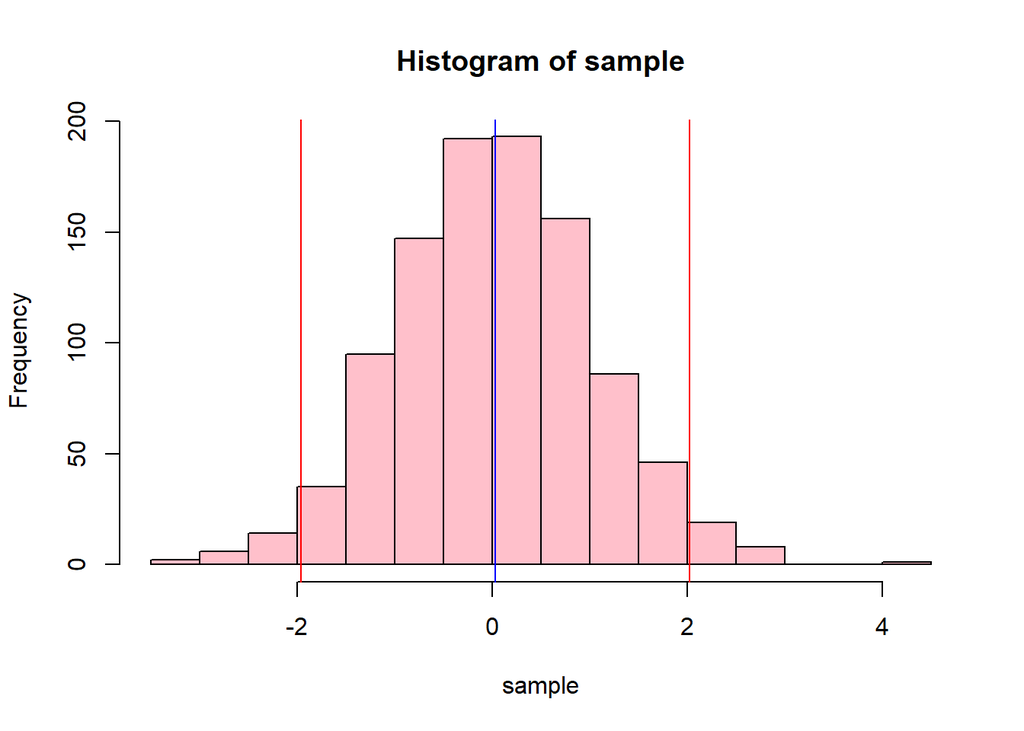

## Variance of means

Now we move a step further and compute the variance of means: instead of picking n random numbers, now we pick n random numbers m time, and each calculate their mean. Afterwards, we’ll see how the variance of means will change when we change n. For this example, we will have *n = 3* and *m = 1000*.

```r
n <- 3
m <- 1000

# Find means of m samples of n
means <- sapply(replicate(m, sapply(n, rnorm, simplify = FALSE)), mean)
variance <- var(means) # variance of means

# What happens if we make sample size larger?
new_n <- n * 100
new_means <- sapply(replicate(m, sapply(new_n, rnorm, simplify = FALSE)), mean)
new_variance <- var(new_means)
# The variance is much smaller!
```